# Tuesday Exercises

## Question 1

### (a)

```r
setwd(dirname(rstudioapi::getActiveDocumentContext()$path))
beetles <- read.table(file="../../data/T5_5_FBeetles.dat",
                      col.names=c("exptUnit",
                                  "species","transvDis","elyLen","ant2Len","ant3Len"))
head(beetles)
```

```
##   exptUnit species transvDis elyLen ant2Len ant3Len
## 1        1       1       189    245     137     163
## 2        2       1       192    260     132     217
## 3        3       1       217    276     141     192
## 4        4       1       221    299     142     213
## 5        5       1       171    239     128     158
## 6        6       1       192    262     147     173
```

### (b)

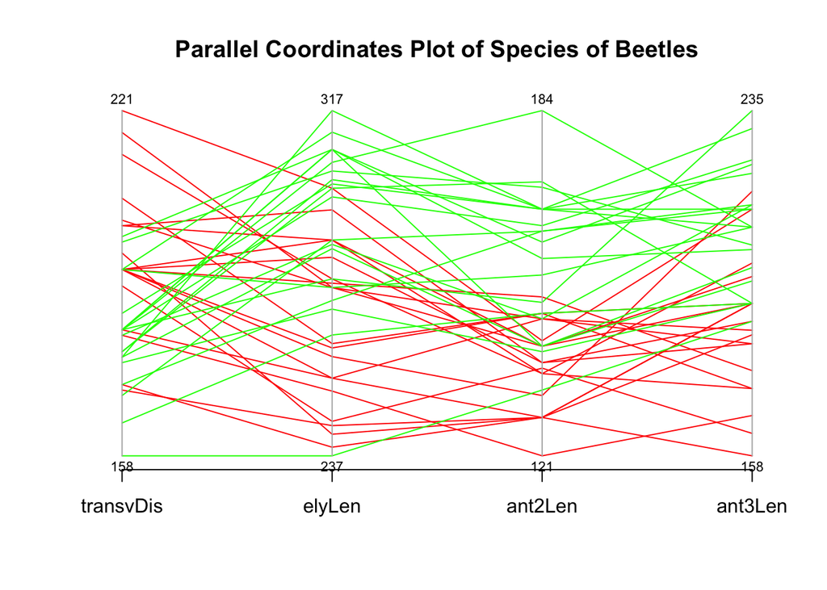

```r
library(MASS)
responses <- beetles[,3:6]
type <- beetles[,2]
colors <- ifelse(type==1, yes="Red", no="Green")
parcoord(responses, var.label=T, col = colors,
         main="Parallel Coordinates Plot of Species of Beetles")
```

Species 1 of the beetles which is the red and Species 2 is the green. From this plot it is clear that the 2 species would have different means for the variables ant3Len and ant2Len as there are clear distinctions between species. However, for the transvDis and elyLen variables, the distinctions are not so clear, which would suggest that there may not be significant differences in those specific variables between the 2 species. In regards to the null hypothesis which is that $\mu_1 = \mu_2$ may be rejected as there are differences between the species in at least some of the variables. However, the $T^2$ test would be able to make a sound conclusion.

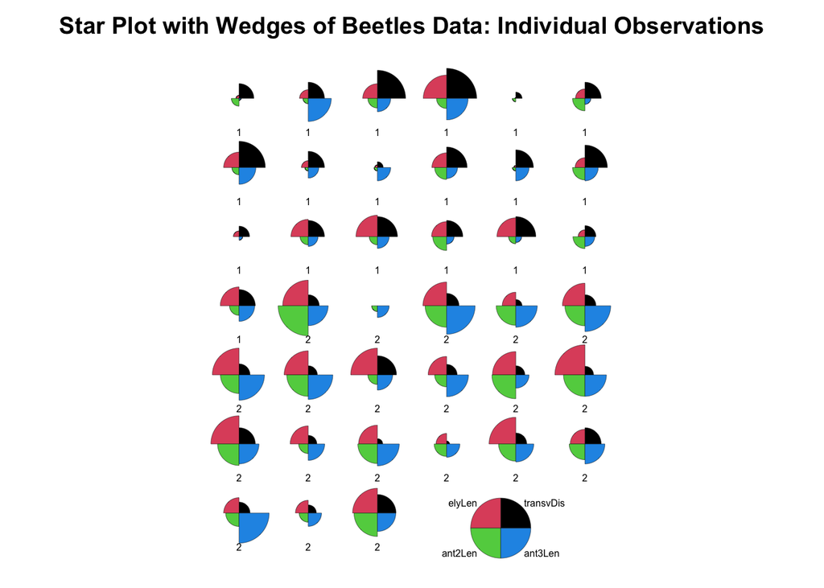

```r
stars(responses, len=1, labels=as.character(beetles$species),
      draw.segments=T, cex=0.5, key.loc=c(11,1.8),
      main="Star Plot with Wedges of Beetles Data: Individual Observations")
```

### (c)

Compute and display the means of the 4 variables, by species. Interpret these figures in the context of the hypothesis test to come as well.

```r
library(dplyr)
means <- beetles |> group_by(species) |> summarize(meanTD=mean(transvDis),
                                                     meanEL=mean(elyLen),
                                                     meanA2=mean(ant2Len),
                                                     meanA3=mean(ant3Len))
means
```

```
## # A tibble: 2 × 5
##   species meanTD meanEL meanA2 meanA3
##     <int>  <dbl>  <dbl>  <dbl>  <dbl>
## 1       1   194.   267.   137.   186.
## 2       2   180.   291.   157.   209.
```

If the null hypothesis is true and the multivariate means are equal for the two species, we would expect the means for each variable to be very similar or equal between the two species. However, the means shown here suggest potential differences between the species for some or all of the variables. The mean for each of the variables tend to different by around 23 with specie 2 having means of elyLen, ant2Len, and ant3Len be larger than specie 1. Each row in that table represents $\bar{y_1}$ and $\bar{y_2}$.

### (d)

#### 5.16 Part (a)

```r
library(DescTools)

responses <- as.matrix(beetles[,3:6])
HotellingsT2Test(responses ~ type, test="f")
```

```
##
##  Hotelling's two sample T2-test
##
## data:  responses by type
## T.2 = 30.666, df1 = 4, df2 = 34, p-value = 7.522e-11
## alternative hypothesis: true location difference is not equal to c(0,0,0,0)
```

There is very strong evidence that the mean beetle measurements differ for the 2 beetle specie (p < 0.0001).

#### 5.16 Part (b)

```r
t.test(beetles$transvDis ~ beetles$species, var=T)
```

```
##
##  Two Sample t-test
##
## data:  beetles$transvDis by beetles$species
## t = 3.8879, df = 37, p-value = 0.0004049
## alternative hypothesis: true difference in means between group 1 and group 2 is not equal to 0
## 95 percent confidence interval:
##   7.146246 22.701122
## sample estimates:
## mean in group 1 mean in group 2
##        194.4737        179.5500
```

```r
t.test(beetles$elyLen ~ beetles$species, var=T)
```

```
##
##  Two Sample t-test
##
## data:  beetles$elyLen by beetles$species
## t = -3.8652, df = 37, p-value = 0.0004326
## alternative hypothesis: true difference in means between group 1 and group 2 is not equal to 0
## 95 percent confidence interval:
##  -36.19595 -11.29879
## sample estimates:
## mean in group 1 mean in group 2
##        267.0526        290.8000
```

```r
t.test(beetles$ant2Len ~ beetles$species, var=T)
```

```
##
##  Two Sample t-test
##
## data:  beetles$ant2Len by beetles$species
## t = -5.6911, df = 37, p-value = 1.645e-06
## alternative hypothesis: true difference in means between group 1 and group 2 is not equal to 0
## 95 percent confidence interval:
##  -26.89214 -12.77101
## sample estimates:
## mean in group 1 mean in group 2
##        137.3684        157.2000
```

```r
t.test(beetles$ant3Len ~ beetles$species, var=T)
```

```
##
##  Two Sample t-test
##
## data:  beetles$ant3Len by beetles$species
## t = -5.0426, df = 37, p-value = 1.236e-05
## alternative hypothesis: true difference in means between group 1 and group 2 is not equal to 0
## 95 percent confidence interval:
##  -32.66593 -13.93933
## sample estimates:
## mean in group 1 mean in group 2
##        185.9474        209.2500
```

Null hypothesis in each of these t tests would be that $\mu_{1i} = \mu_{2i}$ where i = 1,2,3,4 the variables. The p-value in each of the tests resulted in significant results which would mean to reject the null and conclude that there is significant evidence that there is a difference in all of the means between the species.

### (e)

```r
library(MVN)

beetles2 <- beetles[,-1]
mvn(data=beetles2, subset="species", mvnTest="mardia", desc=F)
```

```
## $multivariateNormality
## $multivariateNormality$`1`
##              Test         Statistic            p value Result
## 1 Mardia Skewness  11.1677828131987   0.94175476190961    YES
## 2 Mardia Kurtosis -1.89148607278147 0.0585594883905531    YES
## 3             MVN              <NA>               <NA>    YES
##
## $multivariateNormality$`2`
##              Test          Statistic          p value Result
## 1 Mardia Skewness   17.4388378576225 0.62432170468344    YES
## 2 Mardia Kurtosis -0.777455700518206 0.43688996084037    YES
## 3             MVN               <NA>             <NA>    YES
##
##
## $univariateNormality
## $univariateNormality$`1`
##               Test  Variable Statistic   p value Normality
## 1 Anderson-Darling transvDis    0.4576    0.2356    YES
## 2 Anderson-Darling  elyLen      0.3649    0.4002    YES
## 3 Anderson-Darling  ant2Len     0.3848    0.3578    YES
## 4 Anderson-Darling  ant3Len     0.2293    0.7774    YES
##
## $univariateNormality$`2`
##               Test  Variable Statistic   p value Normality
## 1 Anderson-Darling transvDis    0.4836    0.2035    YES
## 2 Anderson-Darling  elyLen      0.5602    0.1282    YES
## 3 Anderson-Darling  ant2Len     0.4284    0.2809    YES
## 4 Anderson-Darling  ant3Len     0.2488    0.7129    YES
```

Multivariate normality assumption checks out from the output and so we no evidence to suggest beetle measurements are not MV normal.

## Question 2

```r
bronchus <- read.table(file="../../data/T5_10_BRONCUS.dat",
                      col.names=c("y1", "y2","x1","x2"))
bronchus$diff1 <- bronchus$y1 - bronchus$x1
bronchus$diff2 <- bronchus$y2 - bronchus$x2
head(bronchus, n=5)
```

```
##    y1  y2  x1 x2 diff1 diff2
## 1  81  74  72 33     9    41
## 2 461 423 134 18   327   405
## 3  20  16  84 20   -64    -4
## 4 450 450  98 58   352   392
## 5 246  87  48 13   198    74
```

```r
tail(bronchus, n=5)
```

```
##     y1  y2  x1 x2 diff1 diff2
## 12  37  27  87 27   -50     0
## 13 223 218  69 32   154   186
## 14 138 138 100 27    38   111
## 15  72  39 315 39  -243     0
## 16 245 231 188 65    57   166
```

```r
plot(bronchus$diff1, bronchus$diff2,
     xlim=c(-300,450), ylim=c(-300,450), pch=16, xlab="Survival Time (days) from Date of First Hospital Admission", ylab="Survival Time from Date of Untreatability")
title(main="Change in Survival Time from First Hospital Admission by Change in Survival Time from Date of Untreatability\nAscorbate - Control", adj=0)
abline(h=0, v=0, lty=2)

colMeans(bronchus[,5:6])
```

```
##   diff1   diff2
##  49.500 106.875
```

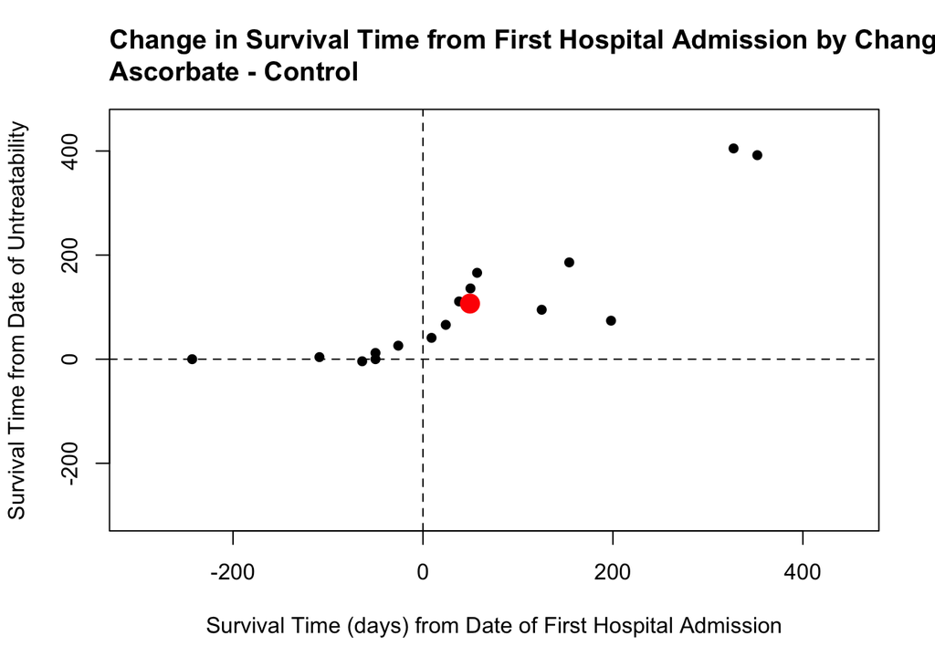

```r
dbar1 <- colMeans(bronchus[,5:6])[1]
dbar2 <- colMeans(bronchus[,5:6])[2]
points(dbar1, dbar2, pch=16, col="red", cex=2)
```

$\bar{d}$ vector contains 49.50 and 106.875 as the mean of the differences for the survival time from date of first hospital admission and the survival time from date of untreatability.

Check if differences are multi-normal:

```r
mvn(data=bronchus[,5:6], subset=NULL, mvnTest="mardia", desc=F)
```

```
## $multivariateNormality
##              Test         Statistic            p value Result
## 1 Mardia Skewness  9.87265788658436 0.0426282532381867     NO
## 2 Mardia Kurtosis 0.985083681306794    0.3245829683979    YES
## 3             MVN              <NA>               <NA>     NO
##
## $univariateNormality
##               Test  Variable Statistic   p value Normality
## 1 Anderson-Darling   diff1      0.3436    0.4421    YES
## 2 Anderson-Darling   diff2      1.1858    0.0030    NO
```

Check if individual variables are normal:

```r
mvn(data=bronchus[,1:4], subset=NULL, mvnTest="mardia", desc=F)
```

```
## $multivariateNormality
##              Test         Statistic              p value Result
## 1 Mardia Skewness  45.8467000881238 0.000845986189337405     NO
## 2 Mardia Kurtosis 0.939236517489355    0.347609323896986    YES
## 3             MVN              <NA>                 <NA>     NO
##
## $univariateNormality
##               Test  Variable Statistic   p value Normality
## 1 Anderson-Darling    y1        0.7974    0.0302    NO
## 2 Anderson-Darling    y2        1.1765    0.0031    NO
## 3 Anderson-Darling    x1        0.9846    0.0099    NO
## 4 Anderson-Darling    x2        0.4930    0.1858    YES
```

```r
HotellingsT2Test(x=bronchus[,5:6], y=NULL, mu=c(0,0), test="f")
```

```
##
##  Hotelling's one sample T2-test
##
## data:  bronchus[, 5:6]
## T.2 = 10.418, df1 = 2, df2 = 14, p-value = 0.001693
## alternative hypothesis: true location is not equal to c(0,0)
```

$H_0: \mu_d = 0$ (difference vector is equal to 0 vector)

$H_1: \mu_d \neq 0$ (difference vector is not equal to the 0 vector)

```r
t.test(x=bronchus$diff1)
```

```
##
##  One Sample t-test
##
## data:  bronchus$diff1
## t = 1.2804, df = 15, p-value = 0.2199
## alternative hypothesis: true mean is not equal to 0
## 95 percent confidence interval:
##  -32.90449 131.90449
## sample estimates:
## mean of x
##      49.5
```

```r
t.test(x=bronchus$diff2)
```

```
##
##  One Sample t-test
##
## data:  bronchus$diff2
## t = 3.3161, df = 15, p-value = 0.004701
## alternative hypothesis: true mean is not equal to 0
## 95 percent confidence interval:
##   38.18028 175.56972
## sample estimates:
## mean of x
##   106.875
```

#### Summary:

There is fairly strong evidence that the mean change in survival time from date of first hospital admission and survival time from date of untreatability are not both 0 (p = 0.001693). Although the p-value may not be accurate due to differences not being multivariate normal. From the follow up analyses, the survival time from date of untreatability changes between patients who received ascorbate and the control (p = 0.004701). While the survival time from date of first hospital admission does not change (p = 0.2199). This means that from the graph the distance from the y = 0 line to the d-bar vector is significant.

## Question 3

### (a)

The $T^2$ statistic is the Mahalanobis distance between the sample means of the 2 beetle species for the beetle measurements.

### (b)

```r
ybar1 <- colMeans(beetles[beetles$species == 1, -c(1,2)])
ybar2 <- colMeans(beetles[beetles$species == 2, -c(1,2)])
ybar1
```

```
## transvDis    elyLen   ant2Len   ant3Len
##  194.4737  267.0526  137.3684  185.9474
```

```r
ybar2
```

```
## transvDis    elyLen   ant2Len   ant3Len
##    179.55    290.80    157.20    209.25
```

```r
s1 <- cov(beetles[beetles$species == 1, -c(1,2)])
s2 <- cov(beetles[beetles$species == 2, -c(1,2)])
s1
```

```
##           transvDis    elyLen  ant2Len   ant3Len
## transvDis 187.59649 176.86257 48.37135 113.58187
## elyLen    176.86257 345.38596 75.97953 118.78070
## ant2Len    48.37135  75.97953 66.35673  16.24269
## ant3Len   113.58187 118.78070 16.24269 239.94152
```

```r
s2
```

```
##           transvDis    elyLen   ant2Len   ant3Len
## transvDis 101.83947 128.06316  36.98947  32.59211
## elyLen    128.06316 389.01053 165.35789  94.36842
## ant2Len    36.98947 165.35789 167.53684  66.52632
## ant3Len    32.59211  94.36842  66.52632 177.88158
```

Get sample sizes of each species:

```r
n1 <- nrow(beetles[beetles$species == 1,])
n2 <- nrow(beetles[beetles$species == 2,])
n1
```

```
## [1] 19
```

```r
n2
```

```
## [1] 20
```

### (c)

Use the objects you created above to compute the T 2 statistic for the test you did in Exercise #1  
earlier. For this, you will need to compute a pooled sample covariance matrix, and you will need to  
invert a matrix.

```r
Sp <- ((n1-1)*s1 + (n2-1)*s2) / (n1+n2-2)
Sp
```

```
##           transvDis   elyLen   ant2Len   ant3Len
## transvDis 143.55910 151.8034  42.52660  71.99253
## elyLen    151.80341 367.7878 121.87653 106.24467
## ant2Len    42.52660 121.8765 118.31408  42.06401
## ant3Len    71.99253 106.2447  42.06401 208.07290
```

```r
T2 <- n1*n2/(n1+n2) * t(ybar1-ybar2) %*% solve(Sp) %*% (ybar1-ybar2)
T2
```

```
##          [,1]
## [1,] 133.4873
```

$T^2$ = 133.487

### (d)

```r
ybar1
```

```
## transvDis    elyLen   ant2Len   ant3Len
##  194.4737  267.0526  137.3684  185.9474
```

The statistic would decrease since now the distance between the sample means would be smaller. The sample means for the ant3len would now be both closer to each other which would decrease the Mahalanobis distance between the sample means.

```r
dybar1 <- colMeans(beetles[beetles$species == 1, -c(1,2)])
dybar1[4] <- 209
dybar1
```

```
## transvDis    elyLen   ant2Len   ant3Len
##  194.4737  267.0526  137.3684  209.0000
```

```r
T2 <- n1*n2/(n1+n2) * t(dybar1-ybar2) %*% solve(Sp) %*% (dybar1-ybar2)
T2
```

```
##          [,1]
## [1,] 100.2046
```

$T^2$ = 100.2046 and the change was as expected since it did decrease.

### (e)

The statistic would increase since now the distance between the sample means would be larger. The sample means for the ant3len would now be farther from each other which would increase the Mahalanobis distance between the sample means.

```r
eybar1 <- colMeans(beetles[beetles$species == 1, -c(1,2)])
eybar1[4] <- 150
eybar1
```

```
## transvDis    elyLen   ant2Len   ant3Len
##  194.4737  267.0526  137.3684  150.0000
```

```r
T2 <- n1*n2/(n1+n2) * t(eybar1-ybar2) %*% solve(Sp) %*% (eybar1-ybar2)
T2
```

```
##        [,1]
## [1,] 309.57
```

$T^2$ = 309.57 and the change was as expected since it did increase.